# Data 606 - Lab 3

Peter Kowalchuk

September 21, 2018

# The Normal Distribution

## The Data

```r
load("more/bdims.RData")
head(bdims)
```

```
##   bia.di bii.di bit.di che.de che.di elb.di wri.di kne.di ank.di sho.gi
## 1   42.9   26.0   31.5   17.7   28.0   13.1   10.4   18.8   14.1  106.2
## 2   43.7   28.5   33.5   16.9   30.8   14.0   11.8   20.6   15.1  110.5
## 3   40.1   28.2   33.3   20.9   31.7   13.9   10.9   19.7   14.1  115.1
## 4   44.3   29.9   34.0   18.4   28.2   13.9   11.2   20.9   15.0  104.5
## 5   42.5   29.9   34.0   21.5   29.4   15.2   11.6   20.7   14.9  107.5
## 6   43.3   27.0   31.5   19.6   31.3   14.0   11.5   18.8   13.9  119.8
##   che.gi wai.gi nav.gi hip.gi thi.gi bic.gi for.gi kne.gi cal.gi ank.gi
## 1   89.5   71.5   74.5   93.5   51.5   32.5   26.0   34.5   36.5   23.5
## 2   97.0   79.0   86.5   94.8   51.5   34.4   28.0   36.5   37.5   24.5
## 3   97.5   83.2   82.9   95.0   57.3   33.4   28.8   37.0   37.3   21.9
## 4   97.0   77.8   78.8   94.0   53.0   31.0   26.2   37.0   34.8   23.0
## 5   97.5   80.0   82.5   98.5   55.4   32.0   28.4   37.7   38.6   24.4
## 6   99.9   82.5   80.1   95.3   57.5   33.0   28.0   36.6   36.1   23.5
##   wri.gi age  wgt   hgt sex
## 1   16.5  21 65.6 174.0   1
## 2   17.0  23 71.8 175.3   1
## 3   16.9  28 80.7 193.5   1
## 4   16.6  23 72.6 186.5   1
## 5   18.0  22 78.8 187.2   1
## 6   16.9  21 74.8 181.5   1
```

```r
mdims <- subset(bdims, sex == 1)
fdims <- subset(bdims, sex == 0)
```

1. Make a histogram of men’s heights and a histogram of women’s heights. How would you compare the various aspects of the two distributions?

```r
m<-hist(mdims$hgt,plot=FALSE)
m
```

```
## $breaks
##  [1] 155 160 165 170 175 180 185 190 195 200
##
## $counts
## [1]  2  5 28 44 76 50 28 12  2
##
## $density
## [1] 0.001619433 0.004048583 0.022672065 0.035627530 0.061538462 0.040485830
## [7] 0.022672065 0.009716599 0.001619433
##
## $mids
## [1] 157.5 162.5 167.5 172.5 177.5 182.5 187.5 192.5 197.5
##
## $xname
## [1] "mdims$hgt"
##
## $equidist
## [1] TRUE
##
## attr(,"class")
## [1] "histogram"
```

```r
f<-hist(fdims$hgt,plot=FALSE)
f
```

```
## $breaks
## [1] 145 150 155 160 165 170 175 180 185
##
## $counts
## [1]  3 15 52 63 69 38 18  2
##
## $density
## [1] 0.002307692 0.011538462 0.040000000 0.048461538 0.053076923 0.029230769
## [7] 0.013846154 0.001538462
##
## $mids
## [1] 147.5 152.5 157.5 162.5 167.5 172.5 177.5 182.5
##
## $xname
## [1] "fdims$hgt"
##
## $equidist
## [1] TRUE
##
## attr(,"class")
## [1] "histogram"
```

```r
h<-rbind(m$density,f$density)
h
```

```
##             [,1]        [,2]       [,3]       [,4]       [,5]       [,6]
## [1,] 0.001619433 0.004048583 0.02267206 0.03562753 0.06153846 0.04048583
## [2,] 0.002307692 0.011538462 0.04000000 0.04846154 0.05307692 0.02923077
##            [,7]        [,8]        [,9]
## [1,] 0.02267206 0.009716599 0.001619433
## [2,] 0.01384615 0.001538462 0.002307692
```

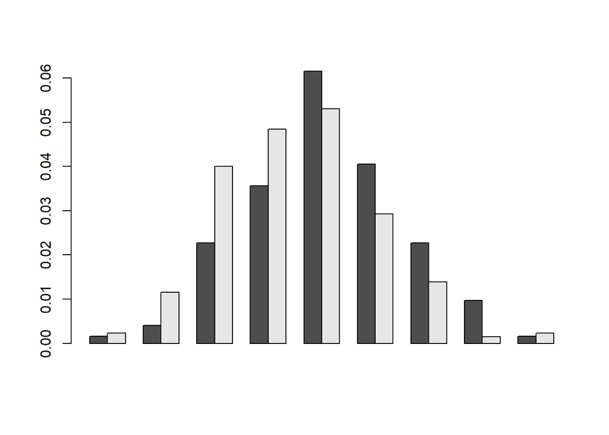

```r
barplot(h,beside = T)
```

```r
mean(mdims$hgt)
```

```
## [1] 177.7453
```

```r
mean(fdims$hgt)
```

```
## [1] 164.8723
```

```r
sd(mdims$hgt)
```

```
## [1] 7.183629
```

```r
sd(fdims$hgt)
```

```
## [1] 6.544602
```

## The normal distribution

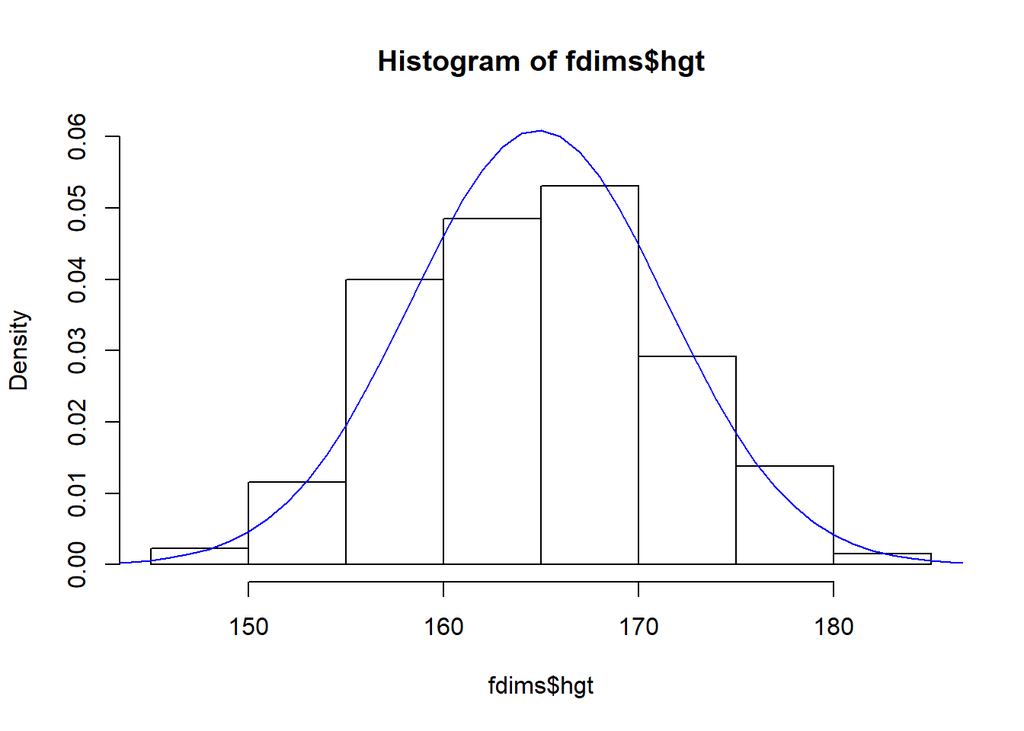

```r
fhgtmean <- mean(fdims$hgt)
fhgtsd   <- sd(fdims$hgt)

hist(fdims$hgt, probability = TRUE, ylim = c(0, 0.06))
x <- 140:190
y <- dnorm(x = x, mean = fhgtmean, sd = fhgtsd)
lines(x = x, y = y, col = "blue")
```

2. Based on the this plot, does it appear that the data follow a nearly normal distribution?

Yes it does, the historgram seems to match the normal distribution line very well.

## Evaluating the normal distribution

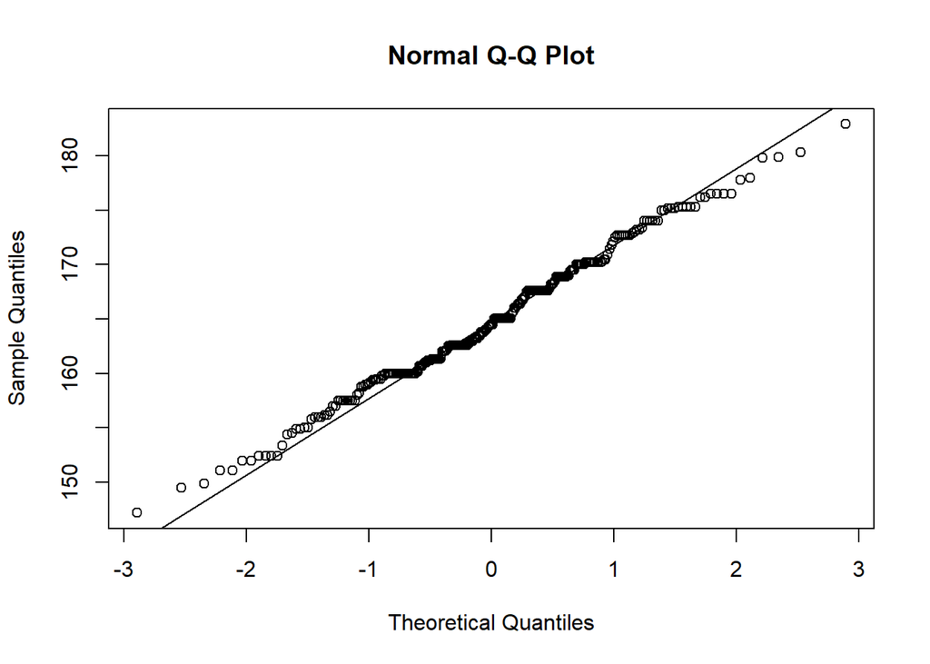

```r
qqnorm(fdims$hgt)
qqline(fdims$hgt)
```

```r
sim_norm <- rnorm(n = length(fdims$hgt), mean = fhgtmean, sd = fhgtsd)
```

3. Make a normal probability plot of `sim_norm`. Do all of the points fall on the line? How does this plot compare to the probability plot for the real data?

No, not all points fall on the line. Similar to the real data, points at the extremes do not follow the line, while points in the middle do.

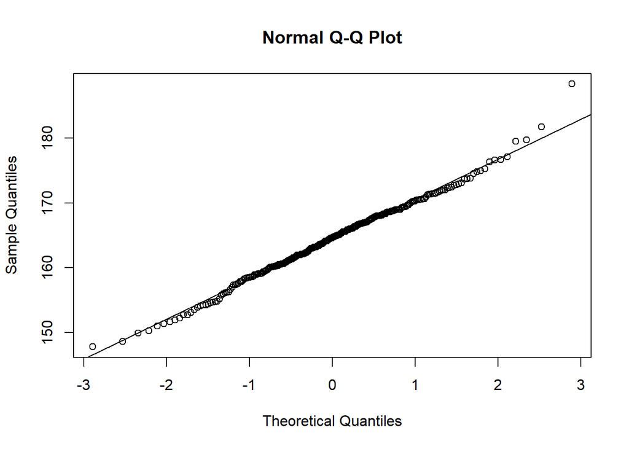

```r
qqnorm(sim_norm)
qqline(sim_norm)
```

4. Does the normal probability plot for `fdims$hgt` look similar to the plots created for the simulated data? That is, do plots provide evidence that the female heights are nearly normal?

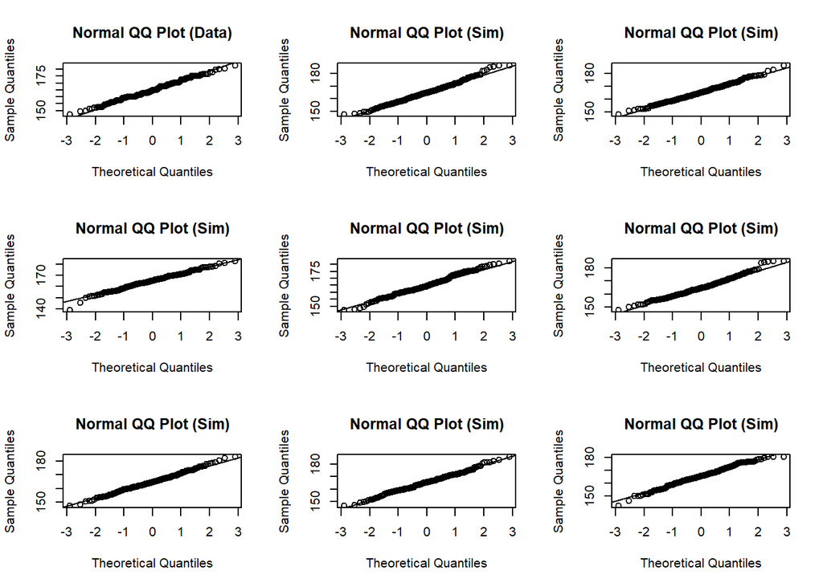

```r
qqnormsim(fdims$hgt)
```

5. Using the same technique, determine whether or not female weights appear to come from a normal distribution.

[figure not shown]

```r
qqnorm(fdims$hgt)
qqline(fdims$hgt)
```

We can also run simulations using the mean and standard deviation of the dataset to see how they compare against a normal distribution. Again, we find most point following the straight line, and therefore we can conclude is is also reasonable to assume a normal distribution.

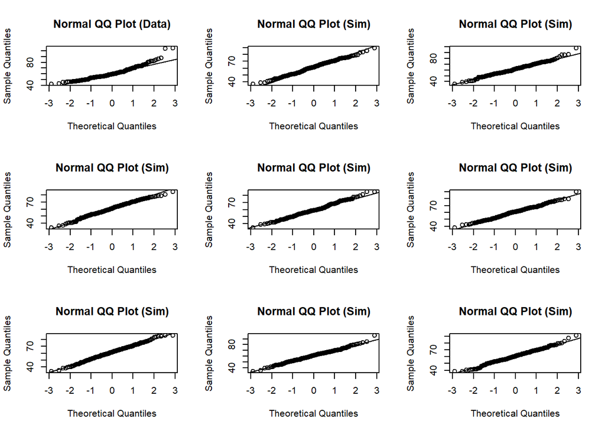

```r
qqnormsim(fdims$wgt)
```

## Normal probabilities

What is the probability that a randomly chosen young adult female is taller than 6 feet (about 182 cm)?

```r
#Usint normal distribution Z values
1 - pnorm(q = 182, mean = fhgtmean, sd = fhgtsd)
```

```
## [1] 0.004434387
```

```r
#empirical solution
sum(fdims$hgt > 182) / length(fdims$hgt)
```

```
## [1] 0.003846154
```

6. Write out two probability questions that you would like to answer; one regarding female heights and one regarding female weights. Calculate the those probabilities using both the theoretical normal distribution as well as the empirical distribution (four probabilities in all). Which variable, height or weight, had a closer agreement between the two methods?

What is the probability that a randomly chosen young adult female is shorter than 5 feet (152.4 cm)?

```r
#Theoretical Normal Distribution
pnorm(q = 152.4, mean = fhgtmean, sd = fhgtsd)
```

```
## [1] 0.028342
```

```r
#Empirical
length(fdims$hgt[fdims$hgt<152.4])/length(fdims$hgt)
```

```
## [1] 0.02692308
```

What is the probability that a randomly chosen young adult female is weights more than 150 lbs (68.0389 Kg)?

```r
#Theoretical Normal Distribution
fwgtmean <- mean(fdims$wgt)
fwgtsd   <- sd(fdims$wgt)
1 - pnorm(q = 68.0389, mean = fwgtmean, sd = fwgtsd)
```

```
## [1] 0.2195895
```

```r
#Empirical
length(fdims$wgt[fdims$wgt>68.0389])/length(fdims$wgt)
```

```
## [1] 0.1923077
```

## On Your Own

- Now let’s consider some of the other variables in the body dimensions data set. Using the figures at the end of the exercises, match the histogram to its normal probability plot. All of the variables have been standardized (first subtract the mean, then divide by the standard deviation), so the units won’t be of any help. If you are uncertain based on these figures, generate the plots in R to check.

  **a.** The histogram for female biiliac (pelvic) diameter (`bii.di`) belongs to normal probability plot letter **B**.

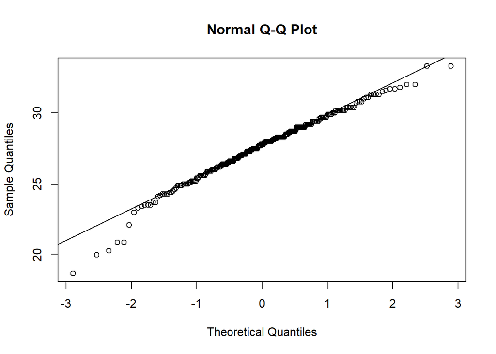

```
**b.** The histogram for female elbow diameter (`elb.di`) belongs to normal
probability plot letter __C__.
```

```r
qqnorm(fdims$bii.di)
qqline(fdims$bii.di)
```

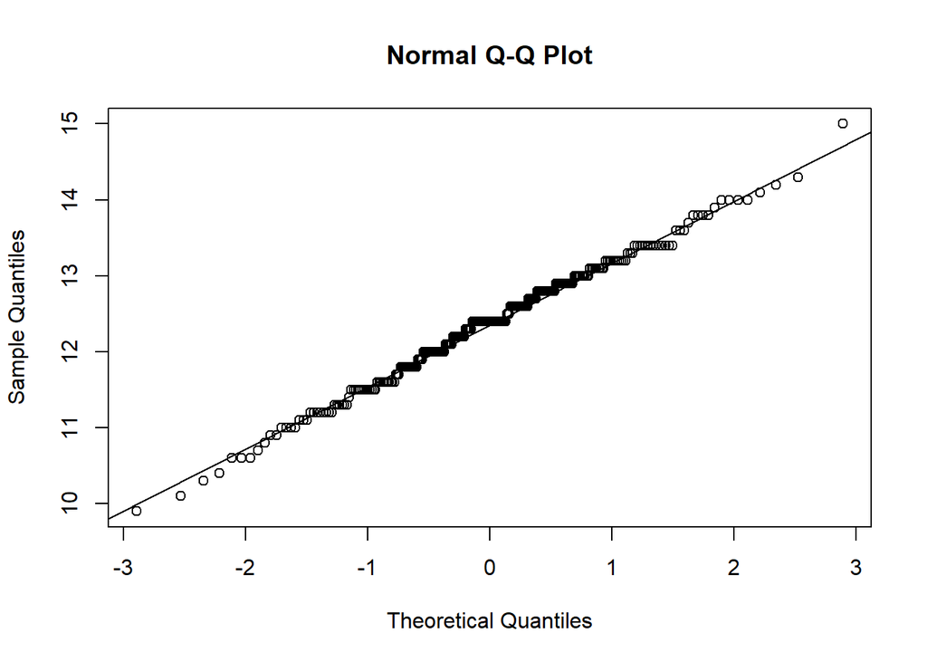

```
**c.** The histogram for general age (`age`) belongs to normal probability
plot letter __D__.
```

```r
qqnorm(fdims$elb.di)
qqline(fdims$elb.di)
```

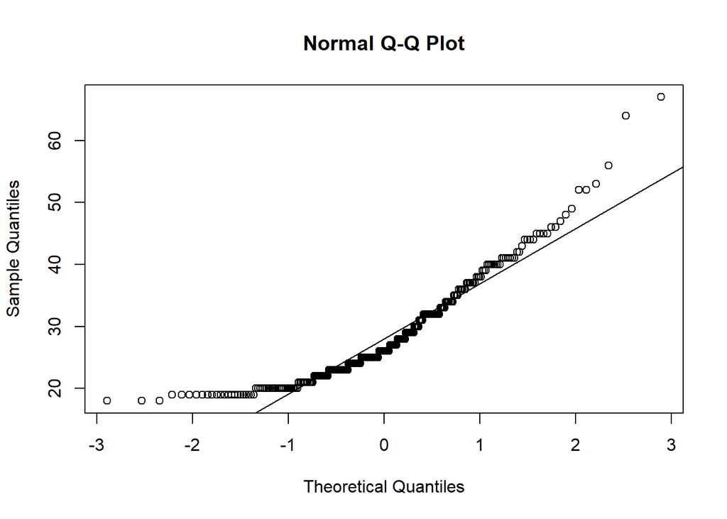

```
**d.** The histogram for female chest depth (`che.de`) belongs to normal
probability plot letter __A__.
```

```r
qqnorm(fdims$age)
qqline(fdims$age)
```

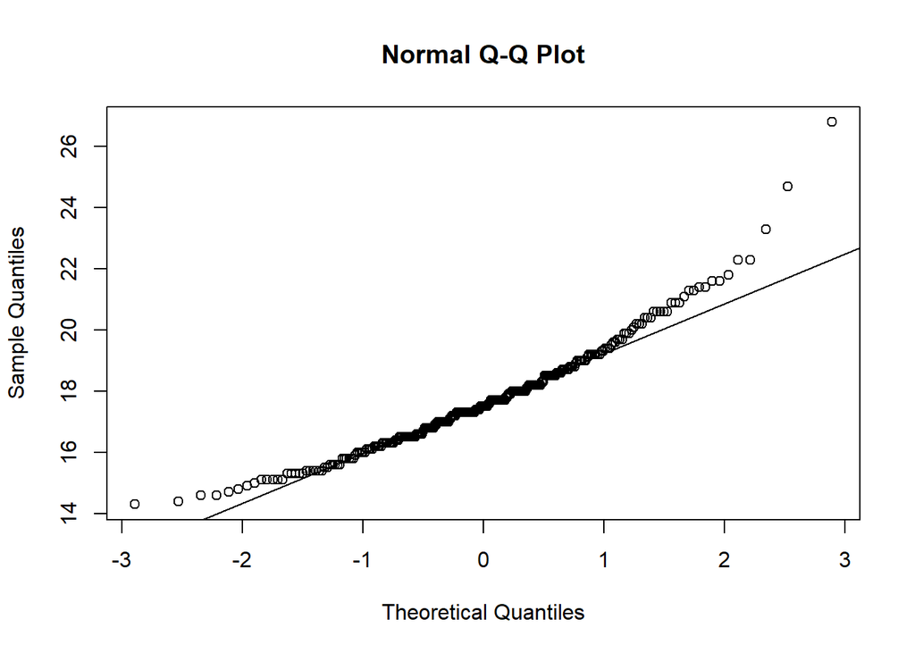

```r
qqnorm(fdims$che.de)
qqline(fdims$che.de)
```

- Note that normal probability plots C and D have a slight stepwise pattern.  
  Why do you think this is the case?

- As you can see, normal probability plots can be used both to assess normality and visualize skewness. Make a normal probability plot for female knee diameter (`kne.di`). Based on this normal probability plot, is this variable left skewed, symmetric, or right skewed? Use a histogram to confirm your findings.

Probability plot show the dataset being right skew, with more point falling off the line towards the righ.

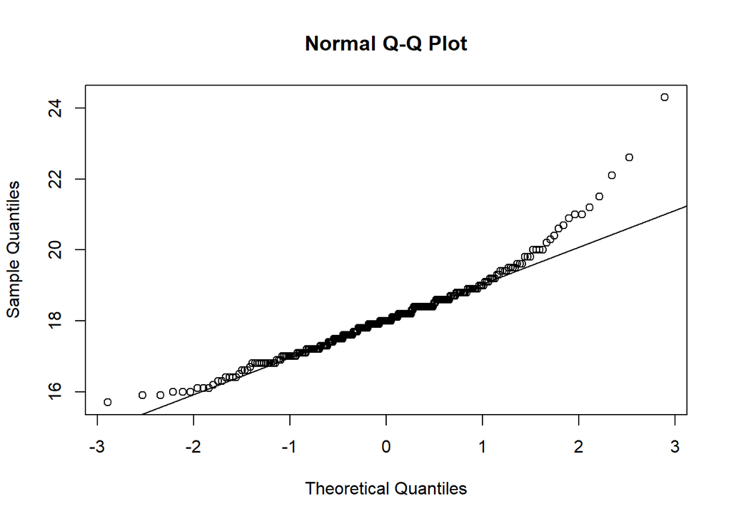

```r
qqnorm(fdims$kne.di)
qqline(fdims$kne.di)
```

The density plot confirms this also showing a histogram which is right skewed.

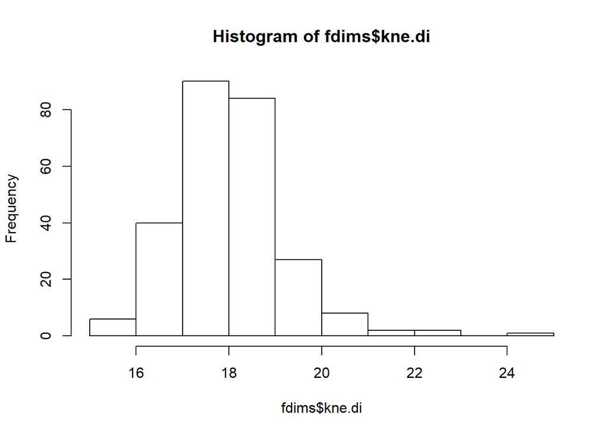

[figure not shown]

```r
hist(fdims$kne.di)
```